# Google Play Store Apps

Los base de datos usada fue extraída de: https://www.kaggle.com/lava18/google-play-store-apps#license.txt

```python
# Librerías bases
import numpy as np
import pandas as pd
import scipy

# Para visualizar
import matplotlib.pyplot as plt
%matplotlib inline
import seaborn as sns


# Para ML
#separar data entrenamiento y prueba
from sklearn.model_selection import train_test_split

#árbol de decisión
from sklearn import tree

#Random Forest
from sklearn.ensemble import RandomForestClassifier
from sklearn.datasets import make_classification

#Revisar ML
from sklearn.metrics import confusion_matrix
from sklearn.metrics import accuracy_score
from sklearn.metrics import auc

from sklearn.tree import export_graphviz
from subprocess import call
```

```python
df=pd.read_csv('./googleplaystore.csv')
```

# Análisis calidad de datos

```python
df.head(5)
```

|  | App | Category | Rating | Reviews | Size | Installs | Type | Price | Content Rating | Genres | Last Updated | Current Ver | Android Ver |
| --- | --- | --- | --- | --- | --- | --- | --- | --- | --- | --- | --- | --- | --- |
| 0 | Photo Editor & Candy Camera & Grid & ScrapBook | ART_AND_DESIGN | 4.1 | 159 | 19M | 10,000+ | Free | 0 | Everyone | Art & Design | January 7, 2018 | 1.0.0 | 4.0.3 and up |
| 1 | Coloring book moana | ART_AND_DESIGN | 3.9 | 967 | 14M | 500,000+ | Free | 0 | Everyone | Art & Design;Pretend Play | January 15, 2018 | 2.0.0 | 4.0.3 and up |
| 2 | U Launcher Lite – FREE Live Cool Themes, Hide ... | ART_AND_DESIGN | 4.7 | 87510 | 8.7M | 5,000,000+ | Free | 0 | Everyone | Art & Design | August 1, 2018 | 1.2.4 | 4.0.3 and up |
| 3 | Sketch - Draw & Paint | ART_AND_DESIGN | 4.5 | 215644 | 25M | 50,000,000+ | Free | 0 | Teen | Art & Design | June 8, 2018 | Varies with device | 4.2 and up |
| 4 | Pixel Draw - Number Art Coloring Book | ART_AND_DESIGN | 4.3 | 967 | 2.8M | 100,000+ | Free | 0 | Everyone | Art & Design;Creativity | June 20, 2018 | 1.1 | 4.4 and up |

```python
rowsiniciales=df.shape[0]
rowsiniciales #10841
#df=df.dropna()
#rowsfinales=df.shape[0]
#rowsfinales
```

```
10841
```

```python
b=df.nunique()
b
```

```
App               9660
Category            34
Rating              40
Reviews           6002
Size               462
Installs            22
Type                 3
Price               93
Content Rating       6
Genres             120
Last Updated      1378
Current Ver       2832
Android Ver         33
dtype: int64
```

Notemos que hay APP que están repetidas. Acá se pueden hacer dos cosas:

- Revisar como varía el ratings u otras variables para una misma App. (aquí hay que revisar la fecha y versión para el análisis). Aunque puede ser que las filas sean simplemente iguales, es decir solo se duplique y no sean fechas distintas de análisis. Acá simplemente no se considerarán las app repetidas. (leer abajo)
- Eliminar App repetidas para considerar las app una sola vez. Así los analisis son más certeros ya que todas las App tienen la misma importancia al final del análisis.

```python
df[df.isnull().any(axis=1)].count()
```

```
App               1481
Category          1481
Rating               7
Reviews           1481
Size              1481
Installs          1481
Type              1480
Price             1481
Content Rating    1480
Genres            1481
Last Updated      1481
Current Ver       1473
Android Ver       1478
dtype: int64
```

Varios columnas vacias

```python
a=df.dtypes
a
```

```
App                object
Category           object
Rating            float64
Reviews            object
Size               object
Installs           object
Type               object
Price              object
Content Rating     object
Genres             object
Last Updated       object
Current Ver        object
Android Ver        object
dtype: object
```

Notemos que **solo Ratings** está en **formato número** y nos gustaría que **install, price, reviews y size** también lo estuvieran (para realizar gráficos es fundamental).

# Data Cleaning

```python
df.drop_duplicates(subset='App', inplace=True)
```

```python
df.nunique()
```

```
App               9660
Category            34
Rating              40
Reviews           5331
Size               462
Installs            22
Type                 3
Price               93
Content Rating       6
Genres             119
Last Updated      1378
Current Ver       2818
Android Ver         33
dtype: int64
```

```python
df.shape[0]
```

```
9660
```

Note Que ahora tenemos el mismo número de filas que de App distintas!

```python
df['Installs']=df.Installs.apply(lambda x: x.replace('+','') if '+' in str(x) else x)
```

```python
#df.head(5) #notemos que esto está bien (quitamos el +) ahora transformemoslo a número!
```

```python
#df['Installs']=df.Installs.apply(lambda x: int(x)) #notemos que arroja error porque hay comas!!!!!  (hay que eliminarlas)
```

```python
df['Installs']=df.Installs.apply(lambda x: x.replace(',','') if ',' in str(x) else x)
```

```python
#df['Installs']=df.Installs.apply(lambda x: int(x)) #arroga otro error porque dentro de las bases hay elementos que dicen Free
```

```python
df=df[df['Installs']!='Free']
```

```python
df['Installs']=df.Installs.apply(lambda x: int(x))
```

```python
df.head(4)
```

|  | App | Category | Rating | Reviews | Size | Installs | Type | Price | Content Rating | Genres | Last Updated | Current Ver | Android Ver |
| --- | --- | --- | --- | --- | --- | --- | --- | --- | --- | --- | --- | --- | --- |
| 0 | Photo Editor & Candy Camera & Grid & ScrapBook | ART_AND_DESIGN | 4.1 | 159 | 19M | 10000 | Free | 0 | Everyone | Art & Design | January 7, 2018 | 1.0.0 | 4.0.3 and up |
| 1 | Coloring book moana | ART_AND_DESIGN | 3.9 | 967 | 14M | 500000 | Free | 0 | Everyone | Art & Design;Pretend Play | January 15, 2018 | 2.0.0 | 4.0.3 and up |
| 2 | U Launcher Lite – FREE Live Cool Themes, Hide ... | ART_AND_DESIGN | 4.7 | 87510 | 8.7M | 5000000 | Free | 0 | Everyone | Art & Design | August 1, 2018 | 1.2.4 | 4.0.3 and up |
| 3 | Sketch - Draw & Paint | ART_AND_DESIGN | 4.5 | 215644 | 25M | 50000000 | Free | 0 | Teen | Art & Design | June 8, 2018 | Varies with device | 4.2 and up |

```python
#df.dtypes #Install está listo
```

mismo ahora con price

```python
#df['Price']=df.Price.apply(lambda x: float(x)) #molestan los $
```

```python
df['Price']=df.Price.apply(lambda x: x.replace('$','') if '$' in str(x) else x)
```

```python
df['Price']=df.Price.apply(lambda x: float(x)) #listo!
```

```python
df['Reviews']=df.Reviews.apply(lambda x: int(x)) #listo!
```

```python
df['Size']=df.Size.apply(lambda x: x.replace('M','') if 'M' in str(x) else x)
```

```python
#df['Size']=df.Size.apply(lambda x: float(x)) #problema con 'Varies with device'
#como argumento ( ojo puede ser útil está variable) se puede ver si se correlaciona positivamente con el ratings
#esto es porque intuitivamente si da libertad de peso de acuerdo al dispositivo deberìa funcionar mejor en todo tipo de dispositivo
#esto es solo una teoría
```

```python
df[df['Size']=='Varies with device'].Rating.mean()
```

```
4.249101796407182
```

```python
df[df['Size']!='Varies with device'].Rating.mean()
```

```
4.160623310089655
```

Notemos que la intuición era correcta!, sin embargo la diferenca es muy poca y sacaremos los valores que tengan 'Varies with device' para trabajar con está variable como número.

```python
df['Size']=df.Size.apply(lambda x: x.replace('Varies with device','NaN') if 'Varies with device' in str(x) else x)
```

```python
#df['Size']=df.Size.apply(lambda x: float(x)) notemos que hay aplicaciones que pesan kilobytes
```

```python
df['Size'] = df.Size.apply(lambda x: float(x.replace('k', '')) / 1000 if 'k' in str(x) else x)
```

```python
del df['Current Ver'] #la versión del aplicativo (se sacará está variable)
```

```python
df.head(4)
```

|  | App | Category | Rating | Reviews | Size | Installs | Type | Price | Content Rating | Genres | Last Updated | Android Ver |
| --- | --- | --- | --- | --- | --- | --- | --- | --- | --- | --- | --- | --- |
| 0 | Photo Editor & Candy Camera & Grid & ScrapBook | ART_AND_DESIGN | 4.1 | 159 | 19 | 10000 | Free | 0.0 | Everyone | Art & Design | January 7, 2018 | 4.0.3 and up |
| 1 | Coloring book moana | ART_AND_DESIGN | 3.9 | 967 | 14 | 500000 | Free | 0.0 | Everyone | Art & Design;Pretend Play | January 15, 2018 | 4.0.3 and up |
| 2 | U Launcher Lite – FREE Live Cool Themes, Hide ... | ART_AND_DESIGN | 4.7 | 87510 | 8.7 | 5000000 | Free | 0.0 | Everyone | Art & Design | August 1, 2018 | 4.0.3 and up |
| 3 | Sketch - Draw & Paint | ART_AND_DESIGN | 4.5 | 215644 | 25 | 50000000 | Free | 0.0 | Teen | Art & Design | June 8, 2018 | 4.2 and up |

```python
df[df.isnull().any(axis=1)].count()
```

```
App               1465
Category          1465
Rating               2
Reviews           1465
Size              1465
Installs          1465
Type              1464
Price             1465
Content Rating    1465
Genres            1465
Last Updated      1465
Android Ver       1463
dtype: int64
```

```python
df=df.dropna()
```

```python
df.nunique()
```

```
App               8194
Category            33
Rating              39
Reviews           5321
Size               414
Installs            19
Type                 2
Price               73
Content Rating       6
Genres             114
Last Updated      1300
Android Ver         31
dtype: int64
```

```python
df['Size'] = df.Size.apply(lambda x: float(x))
```

```python
df.dtypes
```

```
App                object
Category           object
Rating            float64
Reviews             int64
Size              float64
Installs            int64
Type               object
Price             float64
Content Rating     object
Genres             object
Last Updated       object
Android Ver        object
dtype: object
```

```python
df[df.isnull().any(axis=1)].count()
```

```
App               1169
Category          1169
Rating            1169
Reviews           1169
Size                 0
Installs          1169
Type              1169
Price             1169
Content Rating    1169
Genres            1169
Last Updated      1169
Android Ver       1169
dtype: int64
```

```python
df=df.dropna()
```

```python
df.nunique()
```

```
App               7025
Category            33
Rating              39
Reviews           4295
Size               412
Installs            19
Type                 2
Price               68
Content Rating       6
Genres             111
Last Updated      1279
Android Ver         31
dtype: int64
```

```python
df[df.isnull().any(axis=1)].count()
```

```
App               0
Category          0
Rating            0
Reviews           0
Size              0
Installs          0
Type              0
Price             0
Content Rating    0
Genres            0
Last Updated      0
Android Ver       0
dtype: int64
```

# Ordenando los datos

Hipotesis (revisar si la intuición es correcta) [Lluvia de ideas]

- Las App gratuitas tienen mayor Installs.
- Los Rating varían de acuerdo a Categoria, categorias más de nicho tienen una distribución de ratings y review distinta al resto porque las personas que las usan tienen algún conocimiento específicos que las haces más críticos o bien más agradecidos. (ver cómo testear está hipótesis)
- **Si la App es gratuita depende de la categoría, categorías con mayor competencia tienen más App gratuitas.**
- **App pagadas dentro de categorias donde hay más aplicaciones gratuitas tienen muy bajo Install. (gente es más critica con ellas)**
- App más livianas dentro de la misma categoría tienen más descargas y/o mejor nota.
- Aplicaciones con versiones de Android más nuevas tienen peor nota ya que hay muchos usurios sin poderlas usar correctamente.
- Considerar cada categoria como una **industria en el sentido que cada una tiene su rentabilidad** y una **variación de rentabilidad** (recordar: https://aprendeingenieria.com/evidencia-cientifica-estrategia-rentabilidad/). La rentabilidad puede ser una función del Rating y del número de Install. (por ejemplo se multiplican ambas variables. Si está el rating en el promedio se normaliza a 1). Todas las App deben ganar de alguna forma ya sea por publicidad o por que son pagadas.
- Analizar información en base a las cosas que se deciden y las que son un resultado.
  - Deciden: Peso APP, última actualización, Android Ver, categorías, generos, Content Rating y precio
  - Resultados: Installs, Ratings, Reviews

Ideas interesante 1:

- El ratings sobre la nota promedio o mediana (definir en base a los datos) deben tener un indice aumentante **y**. En el promedio y=0 y bajo el promedio un número negativo. Con y una métrica que es:
  - y= (rating_APP - rating_promedio_categoría)*(1+x).
- Por otro lado x es:
  - 0,2 si la APP tiene más reviews que el promedio de reviews de la categoría y -0,2 en caso contrarío.
- Note que **x es el consenso que se tiene en torno a la nota** de la aplicación. E Y indica la calidad. Una aplicacón con muchos reviews y buena nota será una aplicación con un consenso en torno a ella que es buena (en relación a otras de la misma categoría.) Finalmente está componente de calidad se multiplicará asó con Install: Install*(5+y)/5 (se le suma 5 al y para que está componente siempre sea positiva y se divide por 5 para "normalizarla". Ya que una APP promedio tiene y=0) La instuición de está metrica es: bajo el supuesto que el **valor generado de una aplicación** viene dado por la calidad percibida (esto se correlaciona con su uso y periodo que se tiene app en el celular) y el número de usuarios que la descangan. (obviamente esto aplica muy bien en aplicaciones gratuitas con publicidad.)

Idea interesante 2: Antes de meterse a hacer una APP **en una categoria** conviene saber, cuales son las **APP más populares** de ella y las **más comentadas por sus usuarios**. La primera variable es simplemente la APP con más Install en cada categoria. La segunda variable es el ratio entre reviews/Install. Se calcula para cada APP. Las APP con está metrica más altas son las APP más "polémicas". Ya que tienen una taza alta de que al ser descargada su usuario haga un review. aca solo se trabajará con **más review** y ellas serán consideradas las **aplicaciones tipo de la categoria**.

```python
df.describe() #la mediana del rating es 4.3
```

|  | Rating | Reviews | Size | Installs | Price |
| --- | --- | --- | --- | --- | --- |
| count | 7025.000000 | 7.025000e+03 | 7025.000000 | 7.025000e+03 | 7025.000000 |
| mean | 4.160541 | 1.448170e+05 | 21.758756 | 4.469479e+06 | 1.173694 |
| std | 0.559203 | 1.024141e+06 | 22.728166 | 2.714153e+07 | 18.200187 |
| min | 1.000000 | 1.000000e+00 | 0.008500 | 1.000000e+00 | 0.000000 |
| 25% | 4.000000 | 8.400000e+01 | 4.900000 | 1.000000e+04 | 0.000000 |
| 50% | 4.300000 | 1.546000e+03 | 13.000000 | 1.000000e+05 | 0.000000 |
| 75% | 4.500000 | 2.657200e+04 | 31.000000 | 1.000000e+06 | 0.000000 |
| max | 5.000000 | 4.489172e+07 | 100.000000 | 1.000000e+09 | 400.000000 |

```python
number_of_apps_in_Category_free = df[df['Type']=='Free'].Category.value_counts().sort_values(ascending=False)
number_of_apps_in_Category_free=number_of_apps_in_Category_free.to_frame()
number_of_apps_in_Category_free.columns=['Num_APP_free']

number_of_apps_in_Category_paid = df[df['Type']=='Paid'].Category.value_counts().sort_values(ascending=False)
number_of_apps_in_Category_paid=number_of_apps_in_Category_paid.to_frame()
number_of_apps_in_Category_paid.columns=['Num_APP_paid']



#competence = number_of_apps_in_Category_paid.merge(number_of_apps_in_Category_free, on='Category', how='right')
```

```python
#number_of_apps_in_Category_free
```

```python
paid_vs_free= number_of_apps_in_Category_free.merge(number_of_apps_in_Category_paid, how='outer',  left_index=True, right_index=True)
#free_vs_paid
```

```python
paid_vs_free=paid_vs_free.fillna(0)
#paid_vs_free
```

```python
paid_vs_free=paid_vs_free.assign(paid_vs_free= lambda x: (x.Num_APP_paid)/(x.Num_APP_free))
```

```python
paid_vs_free.sort_values(by=['paid_vs_free'], ascending=False)
```

|  | Num_APP_free | Num_APP_paid | paid_vs_free |
| --- | --- | --- | --- |
| PERSONALIZATION | 213 | 61.0 | 0.286385 |
| MEDICAL | 212 | 54.0 | 0.254717 |
| WEATHER | 44 | 6.0 | 0.136364 |
| COMMUNICATION | 170 | 18.0 | 0.105882 |
| FAMILY | 1368 | 144.0 | 0.105263 |
| SPORTS | 201 | 20.0 | 0.099502 |
| GAME | 758 | 74.0 | 0.097625 |
| TOOLS | 571 | 55.0 | 0.096322 |
| PHOTOGRAPHY | 191 | 13.0 | 0.068063 |
| PRODUCTIVITY | 209 | 14.0 | 0.066986 |
| LIFESTYLE | 253 | 16.0 | 0.063241 |
| ART_AND_DESIGN | 56 | 3.0 | 0.053571 |
| FINANCE | 245 | 13.0 | 0.053061 |
| BOOKS_AND_REFERENCE | 134 | 7.0 | 0.052239 |
| EDUCATION | 84 | 4.0 | 0.047619 |
| MAPS_AND_NAVIGATION | 90 | 4.0 | 0.044444 |
| TRAVEL_AND_LOCAL | 135 | 6.0 | 0.044444 |
| HEALTH_AND_FITNESS | 183 | 8.0 | 0.043716 |
| BUSINESS | 214 | 8.0 | 0.037383 |
| PARENTING | 43 | 1.0 | 0.023256 |
| DATING | 120 | 2.0 | 0.016667 |
| ENTERTAINMENT | 63 | 1.0 | 0.015873 |
| FOOD_AND_DRINK | 71 | 1.0 | 0.014085 |
| SHOPPING | 144 | 2.0 | 0.013889 |
| NEWS_AND_MAGAZINES | 152 | 2.0 | 0.013158 |
| SOCIAL | 154 | 2.0 | 0.012987 |
| VIDEO_PLAYERS | 111 | 1.0 | 0.009009 |
| COMICS | 47 | 0.0 | 0.000000 |
| LIBRARIES_AND_DEMO | 61 | 0.0 | 0.000000 |
| AUTO_AND_VEHICLES | 63 | 0.0 | 0.000000 |
| BEAUTY | 37 | 0.0 | 0.000000 |
| EVENTS | 38 | 0.0 | 0.000000 |
| HOUSE_AND_HOME | 50 | 0.0 | 0.000000 |

**Mostrar en sitio está tabla:** Esta tabla está ordenada dada la proporción entre aplicaciones pagadas y gratuitas por categorías. Pese, a que si la aplicación es pagada o no depende del modelo de negocio de la compañia, es importante que antes de decidir esto conozca su mercado. Si usted desea crear una aplicación revise está tabla y vea como se comportan las otras aplicaciones dentro de está categoría. (https://aprendeingenieria.com/modelos-de-negocio-y-estrategia/)

```python
df.columns
```

```
Index(['App', 'Category', 'Rating', 'Reviews', 'Size', 'Installs', 'Type',
       'Price', 'Content Rating', 'Genres', 'Last Updated', 'Android Ver'],
      dtype='object')
```

```python
Rating_promedio=df[['Category','Rating']].groupby('Category').mean()
Rating_promedio=Rating_promedio.sort_values(by=['Rating'], ascending=False)
Rating_promedio.columns=['Rating_promedio']
Rating_promedio
```

| Category | Rating_promedio |
| --- | --- |
| EVENTS | 4.478947 |
| EDUCATION | 4.373864 |
| ART_AND_DESIGN | 4.361017 |
| PARENTING | 4.347727 |
| PERSONALIZATION | 4.324453 |
| BOOKS_AND_REFERENCE | 4.322695 |
| BEAUTY | 4.291892 |
| SOCIAL | 4.257692 |
| WEATHER | 4.242000 |
| GAME | 4.235697 |
| SHOPPING | 4.213014 |
| LIBRARIES_AND_DEMO | 4.203279 |
| SPORTS | 4.200905 |
| HEALTH_AND_FITNESS | 4.191099 |
| FAMILY | 4.179497 |
| COMICS | 4.168085 |
| MEDICAL | 4.162406 |
| ENTERTAINMENT | 4.154688 |
| AUTO_AND_VEHICLES | 4.147619 |
| NEWS_AND_MAGAZINES | 4.143506 |
| PRODUCTIVITY | 4.132735 |
| HOUSE_AND_HOME | 4.128000 |
| PHOTOGRAPHY | 4.114216 |
| FOOD_AND_DRINK | 4.109722 |
| FINANCE | 4.104651 |
| BUSINESS | 4.096396 |
| LIFESTYLE | 4.089963 |
| COMMUNICATION | 4.076596 |
| VIDEO_PLAYERS | 4.021429 |
| TRAVEL_AND_LOCAL | 4.011348 |
| MAPS_AND_NAVIGATION | 4.008511 |
| TOOLS | 4.005911 |
| DATING | 3.963934 |

```python
mas_reviews=df.sort_values(by=['Reviews'], ascending=False) #df.drop_duplicates(subset='App', inplace=True)
mas_reviews.drop_duplicates(subset='Category', keep='first',inplace=True)
```

```python
mas_reviews #Aplicaciones con más comentarios
```

|  | App | Category | Rating | Reviews | Size | Installs | Type | Price | Content Rating | Genres | Last Updated | Android Ver |
| --- | --- | --- | --- | --- | --- | --- | --- | --- | --- | --- | --- | --- |
| 1670 | Clash of Clans | GAME | 4.6 | 44891723 | 98.0 | 100000000 | Free | 0.0 | Everyone 10+ | Strategy | July 15, 2018 | 4.1 and up |
| 378 | UC Browser - Fast Download Private & Secure | COMMUNICATION | 4.5 | 17712922 | 40.0 | 500000000 | Free | 0.0 | Teen | Communication | August 2, 2018 | 4.0 and up |
| 8896 | DU Battery Saver - Battery Charger & Battery Life | TOOLS | 4.5 | 13479633 | 14.0 | 100000000 | Free | 0.0 | Everyone | Tools | June 5, 2018 | 4.0 and up |
| 3975 | Hay Day | FAMILY | 4.5 | 10053186 | 94.0 | 100000000 | Free | 0.0 | Everyone | Casual | June 28, 2018 | 4.0.3 and up |
| 4688 | VivaVideo - Video Editor & Photo Movie | VIDEO_PLAYERS | 4.6 | 9879473 | 40.0 | 100000000 | Free | 0.0 | Teen | Video Players & Editors | August 4, 2018 | 4.1 and up |
| 2938 | PicsArt Photo Studio: Collage Maker & Pic Editor | PHOTOGRAPHY | 4.5 | 7594559 | 34.0 | 100000000 | Free | 0.0 | Teen | Photography | August 6, 2018 | 4.0.3 and up |
| 3360 | CM Launcher 3D - Theme, Wallpapers, Efficient | PERSONALIZATION | 4.6 | 6702776 | 17.0 | 100000000 | Free | 0.0 | Teen | Personalization | August 3, 2018 | 4.0.3 and up |
| 2655 | Wish - Shopping Made Fun | SHOPPING | 4.5 | 6210998 | 15.0 | 100000000 | Free | 0.0 | Everyone | Shopping | August 3, 2018 | 4.1 and up |
| 3945 | Tik Tok - including musical.ly | SOCIAL | 4.4 | 5637451 | 59.0 | 100000000 | Free | 0.0 | Teen | Social | August 3, 2018 | 4.1 and up |
| 3469 | ES File Explorer File Manager | PRODUCTIVITY | 4.6 | 5383985 | 16.0 | 100000000 | Free | 0.0 | Everyone | Productivity | August 3, 2018 | 4.0 and up |
| 8445 | FIFA Soccer | SPORTS | 4.2 | 3909032 | 51.0 | 100000000 | Free | 0.0 | Everyone | Sports | July 31, 2018 | 4.1 and up |
| 4587 | Tinder | LIFESTYLE | 4.0 | 2789775 | 68.0 | 100000000 | Free | 0.0 | Mature 17+ | Lifestyle | August 2, 2018 | 4.4 and up |
| 4725 | Weather & Clock Widget for Android | WEATHER | 4.4 | 2371543 | 11.0 | 50000000 | Free | 0.0 | Everyone | Weather | June 4, 2018 | 4.0.3 and up |
| 874 | Talking Angela | ENTERTAINMENT | 3.7 | 1828284 | 52.0 | 100000000 | Free | 0.0 | Everyone | Entertainment | July 12, 2018 | 4.1 and up |
| 3828 | GPS Navigation & Offline Maps Sygic | MAPS_AND_NAVIGATION | 4.4 | 1421884 | 33.0 | 50000000 | Free | 0.0 | Everyone | Maps & Navigation | July 26, 2018 | 4.0.3 and up |
| 1173 | Chase Mobile | FINANCE | 4.6 | 1374549 | 32.0 | 10000000 | Free | 0.0 | Everyone | Finance | July 23, 2018 | 5.0 and up |
| 194 | OfficeSuite : Free Office + PDF Editor | BUSINESS | 4.3 | 1002861 | 35.0 | 100000000 | Free | 0.0 | Everyone | Business | August 2, 2018 | 4.1 and up |
| 3736 | Google News | NEWS_AND_MAGAZINES | 3.9 | 877635 | 13.0 | 1000000000 | Free | 0.0 | Teen | News & Magazines | August 1, 2018 | 4.4 and up |
| 3122 | GasBuddy: Find Cheap Gas | TRAVEL_AND_LOCAL | 4.6 | 751551 | 42.0 | 10000000 | Free | 0.0 | Mature 17+ | Travel & Local | August 2, 2018 | 4.4 and up |
| 7229 | Pregnancy Tracker & Countdown to Baby Due Date | PARENTING | 4.7 | 658087 | 62.0 | 10000000 | Free | 0.0 | Everyone | Parenting | May 24, 2018 | 5.0 and up |
| 1183 | Tastely | FOOD_AND_DRINK | 4.7 | 611136 | 19.0 | 10000000 | Free | 0.0 | Everyone | Food & Drink | July 13, 2018 | 4.0.3 and up |
| 1361 | Period Tracker Clue: Period and Ovulation Tracker | HEALTH_AND_FITNESS | 4.8 | 570242 | 20.0 | 10000000 | Free | 0.0 | Everyone | Health & Fitness | August 2, 2018 | 4.1 and up |
| 5323 | Al Quran Indonesia | BOOKS_AND_REFERENCE | 4.8 | 445756 | 16.0 | 10000000 | Free | 0.0 | Everyone | Books & Reference | May 15, 2018 | 4.0 and up |
| 1446 | Zillow: Find Houses for Sale & Apartments for ... | HOUSE_AND_HOME | 4.5 | 417907 | 34.0 | 10000000 | Free | 0.0 | Everyone | House & Home | August 1, 2018 | 4.4 and up |
| 718 | Math Tricks | EDUCATION | 4.5 | 342918 | 8.1 | 10000000 | Free | 0.0 | Everyone | Education | July 29, 2018 | 4.0 and up |
| 10729 | MX Player Codec (ARMv7) | LIBRARIES_AND_DEMO | 4.3 | 332083 | 6.3 | 10000000 | Free | 0.0 | Everyone | Libraries & Demo | April 23, 2018 | 4.0 and up |
| 483 | OkCupid Dating | DATING | 4.1 | 285726 | 15.0 | 10000000 | Free | 0.0 | Mature 17+ | Dating | July 30, 2018 | 4.1 and up |
| 72 | Android Auto - Maps, Media, Messaging & Voice | AUTO_AND_VEHICLES | 4.2 | 271920 | 16.0 | 10000000 | Free | 0.0 | Teen | Auto & Vehicles | July 11, 2018 | 5.0 and up |
| 304 | Manga Rock - Best Manga Reader | COMICS | 4.4 | 238970 | 28.0 | 1000000 | Free | 0.0 | Teen | Comics | July 9, 2018 | 5.0 and up |
| 19 | ibis Paint X | ART_AND_DESIGN | 4.6 | 224399 | 31.0 | 10000000 | Free | 0.0 | Everyone | Art & Design | July 30, 2018 | 4.1 and up |
| 2319 | My Calendar - Period Tracker | MEDICAL | 4.7 | 156410 | 14.0 | 5000000 | Free | 0.0 | Everyone | Medical | August 3, 2018 | 4.1 and up |
| 99 | ipsy: Makeup, Beauty, and Tips | BEAUTY | 4.9 | 49790 | 14.0 | 1000000 | Free | 0.0 | Everyone | Beauty | November 9, 2017 | 4.1 and up |
| 1005 | Ticketmaster Event Tickets | EVENTS | 4.0 | 40113 | 36.0 | 5000000 | Free | 0.0 | Everyone | Events | July 23, 2018 | Varies with device |

```python
mejor_rating=df[df['Reviews']>=10000].sort_values(by=['Rating'], ascending=False) # considerar solo aplicaciones con varios reviews
mejor_rating.drop_duplicates(subset='Category', keep='first',inplace=True)
mejor_rating
```

|  | App | Category | Rating | Reviews | Size | Installs | Type | Price | Content Rating | Genres | Last Updated | Android Ver |
| --- | --- | --- | --- | --- | --- | --- | --- | --- | --- | --- | --- | --- |
| 1260 | Six Pack in 30 Days - Abs Workout | HEALTH_AND_FITNESS | 4.9 | 272337 | 13.000 | 10000000 | Free | 0.00 | Everyone | Health & Fitness | June 21, 2018 | 4.2 and up |
| 79 | Tickets + PDA 2018 Exam | AUTO_AND_VEHICLES | 4.9 | 197136 | 38.000 | 1000000 | Free | 0.00 | Everyone | Auto & Vehicles | July 15, 2018 | 4.1 and up |
| 4975 | Solitaire: Decked Out Ad Free | GAME | 4.9 | 37302 | 35.000 | 500000 | Free | 0.00 | Everyone | Card | May 8, 2017 | 4.1 and up |
| 7000 | PixPanda - Color by Number Pixel Art Coloring ... | FAMILY | 4.9 | 55723 | 14.000 | 1000000 | Free | 0.00 | Everyone | Entertainment | June 4, 2018 | 4.0.3 and up |
| 99 | ipsy: Makeup, Beauty, and Tips | BEAUTY | 4.9 | 49790 | 14.000 | 1000000 | Free | 0.00 | Everyone | Beauty | November 9, 2017 | 4.1 and up |
| 10254 | FC Porto | SPORTS | 4.9 | 15883 | 21.000 | 100000 | Free | 0.00 | Everyone | Sports | June 19, 2018 | 4.0.3 and up |
| 712 | Learn Japanese, Korean, Chinese Offline & Free | EDUCATION | 4.9 | 133136 | 26.000 | 1000000 | Free | 0.00 | Everyone | Education;Education | July 20, 2018 | 4.2 and up |
| 5323 | Al Quran Indonesia | BOOKS_AND_REFERENCE | 4.8 | 445756 | 16.000 | 10000000 | Free | 0.00 | Everyone | Books & Reference | May 15, 2018 | 4.0 and up |
| 3848 | GPS Speedometer and Odometer | MAPS_AND_NAVIGATION | 4.8 | 15865 | 3.300 | 1000000 | Free | 0.00 | Everyone | Maps & Navigation | August 3, 2018 | 4.1 and up |
| 4038 | DU Recorder – Screen Recorder, Video Editor, Live | VIDEO_PLAYERS | 4.8 | 2588730 | 9.700 | 50000000 | Free | 0.00 | Everyone | Video Players & Editors | July 30, 2018 | 5.0 and up |
| 3658 | Weather Live Pro | WEATHER | 4.8 | 17493 | 11.000 | 100000 | Paid | 4.49 | Everyone | Weather | April 20, 2018 | 4.4 and up |
| 1092 | Even - organize your money, get paid early | FINANCE | 4.8 | 12304 | 21.000 | 100000 | Free | 0.00 | Everyone | Finance | August 2, 2018 | 5.0 and up |
| 6407 | WebComics | COMICS | 4.8 | 33783 | 6.400 | 1000000 | Free | 0.00 | Teen | Comics | July 28, 2018 | 4.1 and up |
| 438 | Should I Answer? | COMMUNICATION | 4.8 | 237468 | 8.800 | 1000000 | Free | 0.00 | Everyone | Communication | July 26, 2018 | 4.0 and up |
| 1647 | Nature Sounds | LIFESTYLE | 4.8 | 28588 | 24.000 | 1000000 | Free | 0.00 | Everyone | Lifestyle | March 1, 2018 | 4.0.3 and up |
| 4292 | KPOP Amino for K-Pop Entertainment | SOCIAL | 4.8 | 19047 | 63.000 | 100000 | Free | 0.00 | Teen | Social | July 13, 2018 | 4.0.3 and up |
| 235 | Tiny Scanner Pro: PDF Doc Scan | BUSINESS | 4.8 | 10295 | 39.000 | 100000 | Paid | 4.99 | Everyone | Business | April 11, 2017 | 3.0 and up |
| 3303 | Calculator with Percent (Free) | TOOLS | 4.8 | 48211 | 7.400 | 1000000 | Free | 0.00 | Everyone | Tools | November 18, 2017 | 4.1 and up |
| 2803 | FreePrints – Free Photos Delivered | PHOTOGRAPHY | 4.8 | 109500 | 37.000 | 1000000 | Free | 0.00 | Everyone | Photography | August 2, 2018 | 4.1 and up |
| 2333 | Pregnancy Calculator and Tracker app | MEDICAL | 4.8 | 69126 | 61.000 | 1000000 | Free | 0.00 | Everyone | Medical | June 1, 2018 | 4.1 and up |
| 3141 | Yoriza Pension - travel, lodging, pension, cam... | TRAVEL_AND_LOCAL | 4.8 | 17882 | 86.000 | 1000000 | Free | 0.00 | Everyone | Travel & Local | August 3, 2018 | 5.0 and up |
| 6213 | ALL-IN-ONE PACKAGE TRACKING | PRODUCTIVITY | 4.7 | 167406 | 18.000 | 1000000 | Free | 0.00 | Everyone | Productivity | July 23, 2018 | 4.0.3 and up |
| 882 | 🔥 Football Wallpapers 4K \| Full HD Backgrounds 😍 | ENTERTAINMENT | 4.7 | 11661 | 4.000 | 1000000 | Free | 0.00 | Everyone | Entertainment | July 14, 2018 | 4.0.3 and up |
| 1183 | Tastely | FOOD_AND_DRINK | 4.7 | 611136 | 19.000 | 10000000 | Free | 0.00 | Everyone | Food & Drink | July 13, 2018 | 4.0.3 and up |
| 5335 | Al Mayadeen | NEWS_AND_MAGAZINES | 4.7 | 13620 | 9.000 | 500000 | Free | 0.00 | Everyone | News & Magazines | April 16, 2018 | 4.1 and up |
| 7229 | Pregnancy Tracker & Countdown to Baby Due Date | PARENTING | 4.7 | 658087 | 62.000 | 10000000 | Free | 0.00 | Everyone | Parenting | May 24, 2018 | 5.0 and up |
| 7538 | CM Launcher 3D Pro💎 | PERSONALIZATION | 4.7 | 23802 | 0.173 | 100000 | Paid | 4.99 | Everyone | Personalization | November 17, 2016 | 4.0 and up |
| 2 | U Launcher Lite – FREE Live Cool Themes, Hide ... | ART_AND_DESIGN | 4.7 | 87510 | 8.700 | 5000000 | Free | 0.00 | Everyone | Art & Design | August 1, 2018 | 4.0.3 and up |
| 2771 | ASOS | SHOPPING | 4.7 | 181798 | 22.000 | 10000000 | Free | 0.00 | Everyone | Shopping | July 30, 2018 | 4.4 and up |
| 1466 | Redfin Real Estate | HOUSE_AND_HOME | 4.6 | 36857 | 19.000 | 1000000 | Free | 0.00 | Everyone | House & Home | July 25, 2018 | 5.0 and up |
| 515 | Dating for 50 plus Mature Singles – FINALLY | DATING | 4.6 | 13046 | 13.000 | 500000 | Free | 0.00 | Mature 17+ | Dating | July 31, 2018 | 4.1 and up |
| 1549 | Cool Popular Ringtones 2018 🔥 | LIBRARIES_AND_DEMO | 4.5 | 60170 | 28.000 | 1000000 | Free | 0.00 | Everyone | Libraries & Demo | July 13, 2018 | 5.0 and up |
| 1011 | SeatGeek – Tickets to Sports, Concerts, Broadway | EVENTS | 4.4 | 15558 | 26.000 | 1000000 | Free | 0.00 | Everyone | Events | August 3, 2018 | 5.0 and up |

Note que está tabla es interesante ya que dice que en la **categoria de eventos la mejor aplicación tiene 4,4** (mala nota). Notese que se tiene la restricción de sobre los 10.000 reviews (esto para tener una nota validada por varios usuarios). Es decir, puede ser interesante incursionar con una aplicación en esta categoria.

```python
df_review=df[df['Reviews']>=1000]

Rating_promedio2=df_review[['Category','Rating']].groupby('Category').mean()
Rating_promedio2=Rating_promedio2.sort_values(by=['Rating'], ascending=False)
Rating_promedio2.columns=['Rating_promedio']
Rating_promedio2
```

| Category | Rating_promedio |
| --- | --- |
| ART_AND_DESIGN | 4.473913 |
| EDUCATION | 4.411429 |
| BOOKS_AND_REFERENCE | 4.408197 |
| HEALTH_AND_FITNESS | 4.388889 |
| EVENTS | 4.358333 |
| PARENTING | 4.355000 |
| MEDICAL | 4.353704 |
| PERSONALIZATION | 4.326515 |
| SOCIAL | 4.322222 |
| FINANCE | 4.321154 |
| AUTO_AND_VEHICLES | 4.318519 |
| BEAUTY | 4.307143 |
| WEATHER | 4.295349 |
| PRODUCTIVITY | 4.273950 |
| GAME | 4.271626 |
| SHOPPING | 4.257843 |
| NEWS_AND_MAGAZINES | 4.246269 |
| BUSINESS | 4.244776 |
| SPORTS | 4.241304 |
| MAPS_AND_NAVIGATION | 4.231111 |
| FOOD_AND_DRINK | 4.204255 |
| FAMILY | 4.202445 |
| PHOTOGRAPHY | 4.200709 |
| TOOLS | 4.193525 |
| COMMUNICATION | 4.187879 |
| VIDEO_PLAYERS | 4.183099 |
| ENTERTAINMENT | 4.175410 |
| HOUSE_AND_HOME | 4.140541 |
| COMICS | 4.132000 |
| TRAVEL_AND_LOCAL | 4.122727 |
| LIBRARIES_AND_DEMO | 4.104545 |
| LIFESTYLE | 4.086538 |
| DATING | 3.973333 |

**Será esta diferencia estadísticamente significativa?**

# Análsis visual

```python
df_short=df[df['Reviews']>=100]
df_fix=df_short.copy()
#df_short

#ESTO ES DEBIDO A QUE SON MUY POCOS APP CON ESTÁS CARACTERÍSTICAS
df_fix=df_fix[df_fix['Content Rating'] != 'Adults only 18+']
df_fix=df_fix[df_fix['Content Rating'] != 'Unrated']
```

```python
df_fix['installs']=df_fix['Installs'].apply(lambda x: np.log(x))
df_fix['reviews']=df_fix['Reviews'].apply(lambda x: np.log(x))
```

```python
number_of_apps_in_category = df_short['Category'].value_counts().sort_values(ascending=False)
df_short.columns
```

```
Index(['App', 'Category', 'Rating', 'Reviews', 'Size', 'Installs', 'Type',
       'Price', 'Content Rating', 'Genres', 'Last Updated', 'Android Ver'],
      dtype='object')
```

```python
number_of_apps_in_category
```

```
FAMILY                 1099
GAME                    751
TOOLS                   430
PERSONALIZATION         188
SPORTS                  185
FINANCE                 183
LIFESTYLE               174
PHOTOGRAPHY             166
PRODUCTIVITY            155
HEALTH_AND_FITNESS      148
COMMUNICATION           132
SHOPPING                122
MEDICAL                 117
SOCIAL                  115
BUSINESS                113
NEWS_AND_MAGAZINES      104
TRAVEL_AND_LOCAL         98
BOOKS_AND_REFERENCE      94
DATING                   89
EDUCATION                85
VIDEO_PLAYERS            83
MAPS_AND_NAVIGATION      66
ENTERTAINMENT            64
FOOD_AND_DRINK           61
ART_AND_DESIGN           50
WEATHER                  47
HOUSE_AND_HOME           47
AUTO_AND_VEHICLES        46
COMICS                   40
LIBRARIES_AND_DEMO       38
PARENTING                33
BEAUTY                   24
EVENTS                   22
Name: Category, dtype: int64
```

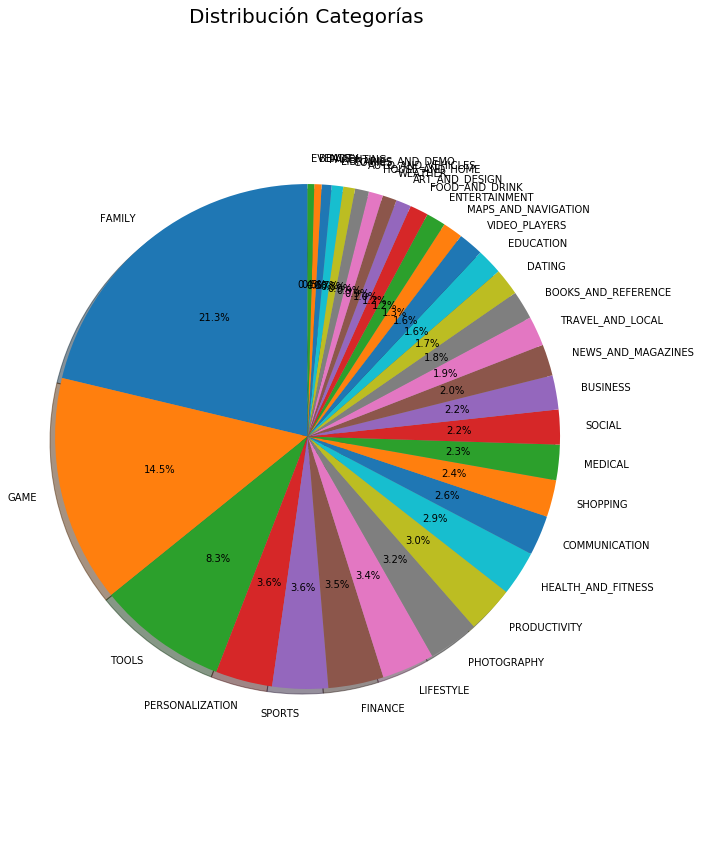

```python
number_of_apps_in_category = df_fix['Category'].value_counts()
number_of_apps_in_category


labels = number_of_apps_in_category.index
values = number_of_apps_in_category.values


fig1, ax1 = plt.subplots(figsize=(10, 15))
ax1.pie(values, labels=labels, autopct='%1.1f%%',
        shadow=True, startangle=90)
ax1.axis('equal')
plt.title("Distribución Categorías", size = 20)
plt.show()
```

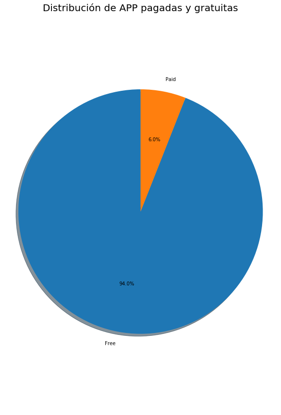

```python
number_of_apps_for_type = df_fix['Type'].value_counts()
number_of_apps_for_type


labels = number_of_apps_for_type.index
values = number_of_apps_for_type.values


fig1, ax1 = plt.subplots(figsize=(10, 15))
ax1.pie(values, labels=labels, autopct='%1.1f%%',
        shadow=True, startangle=90)
ax1.axis('equal')
plt.title("Distribución de APP pagadas y gratuitas", size = 20)
plt.show()
```

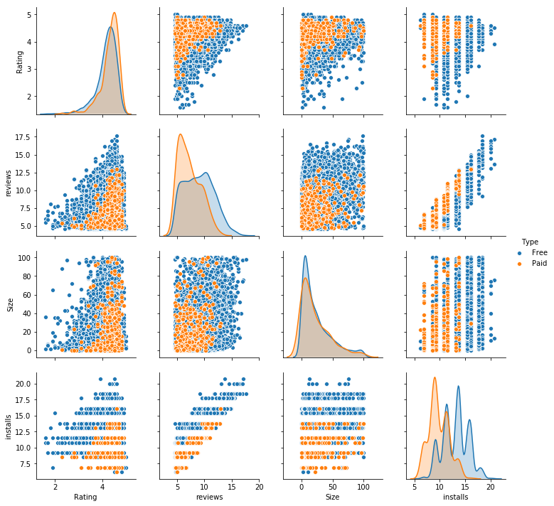

```python
g=sns.pairplot(df_fix,vars=['Rating', 'reviews', 'Size', 'installs'], hue='Type')
```

**Análisis**:

Se ha marcado en negrita los resultados no triviales de estos gráficos.

Viendo **solo la diagonal** de este gráfico se observa que:

Las aplicaciones pagadas tienen mucho menos instalaciones y reviews (A ambos atributos se le aplico logaritmo). **Pero mejor Rating**.

Al mirar a los gráficos **no presentes en las diagonales**.

**Las aplicaciones pagadas tienen un review bastante alto dado sus instalaciones.**

En general las aplicaciones con mejor nota tiene más descarga.

En la distribución de tamaño en MB las pagadas y gratis distribuyen relativamente igual.

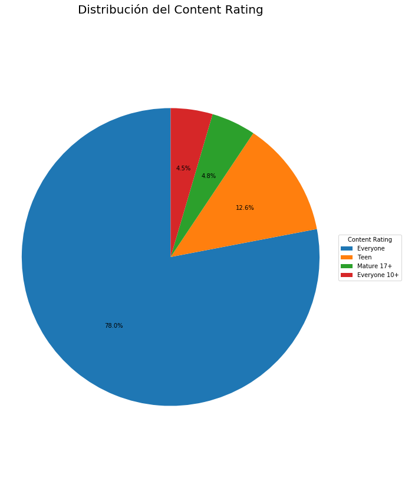

```python
number_of_apps_in_content_rating = df_fix['Content Rating'].value_counts()
number_of_apps_in_content_rating


labels = number_of_apps_in_content_rating.index
values = number_of_apps_in_content_rating.values




fig1, ax1 = plt.subplots(figsize=(10, 15))
ax1.pie(values, autopct='%1.1f%%',
         startangle=90)
ax1.axis('equal')
plt.title("Distribución del Content Rating", size = 20)

ax1.legend(labels,
          title="Content Rating",
          loc="center left",
          bbox_to_anchor=(1, 0, 0.5, 1))

plt.show()
```

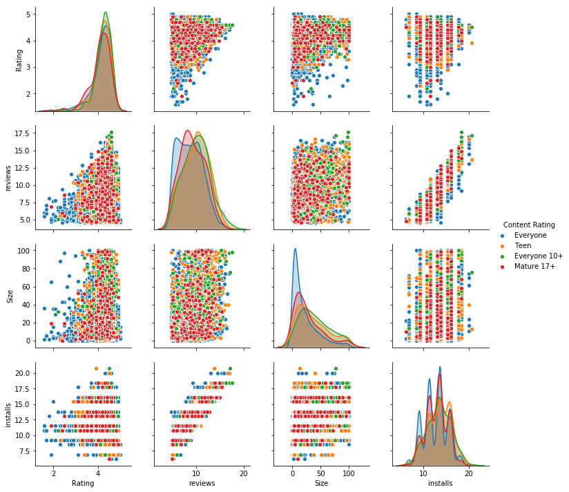

```python
a=sns.pairplot(df_fix,vars=['Rating', 'reviews', 'Size', 'installs'], hue='Content Rating')
```

**(Dado los pocos datos de Adults only 18+ y Unrated no se considerarán en el análisis.)** (note que los colores se inviertieron en mature 17+ y everyone 10+) De la diagonal del gráfico se observa que: las APP "para todos los sobre 10" años son las que distribuyen de forma más diferente al resto. Tienen más rating y más review para una misma cantidad de install que las App de otros contenidos. Por otra parte categorías para everyone son las que tienen menos review para la misma cantidad de install y son las App más livianas.

```python
number_of_apps_in_category = df_fix['Category'].value_counts().sort_values(ascending=False)
#number_of_apps_in_category
```

```python
number_of_apps_in_category = df[df['Content Rating']=='Everyone 10+'].Category.value_counts().sort_values(ascending=False)
#number_of_apps_in_category
```

Las App de content rating igual a everyone 10+ son principalmente juegos por ende es "esperable que pesen más MB" que el resto.

```python
number_of_apps_in_category = df[df['Content Rating']=='Everyone'].Category.value_counts().sort_values(ascending=False)
#number_of_apps_in_category
```

```python
df_fix1=df_fix[df_fix['Price']!=0]
```

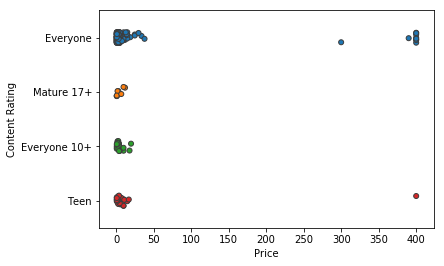

```python
p = sns.stripplot(x="Price", y="Content Rating", data=df_fix1, jitter=True, linewidth=1)
```

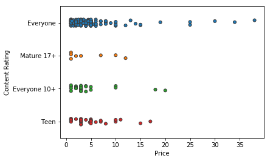

```python
p = sns.stripplot(x="Price", y="Content Rating", data=df_fix1[df_fix1['Price']<100], jitter=True, linewidth=1)
```

Pese a que everyone 10+ y mature 17+ tienen casi la misma cantidad de Apps, Everyone 10+ posee mucha más Apps pagadas.

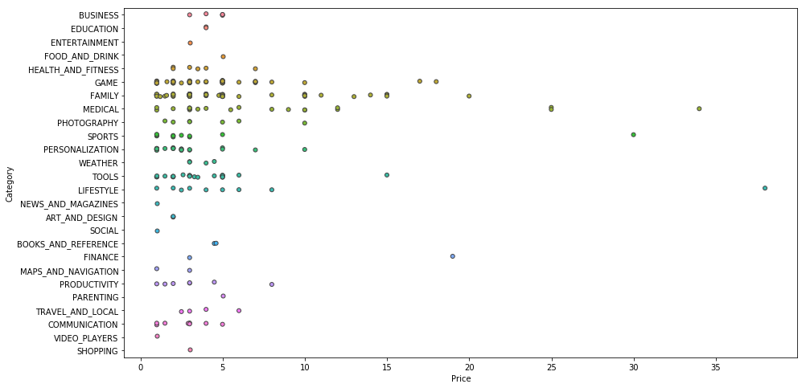

```python
fig, ax = plt.subplots()
fig.set_size_inches(15, 8)
p = sns.stripplot(x="Price", y="Category", data=df_fix1[df_fix1['Price']<100], jitter=True, linewidth=1)
```

Ahora que sabe esta distribución por precio, ¿Cuál es el mejor precio para su App?

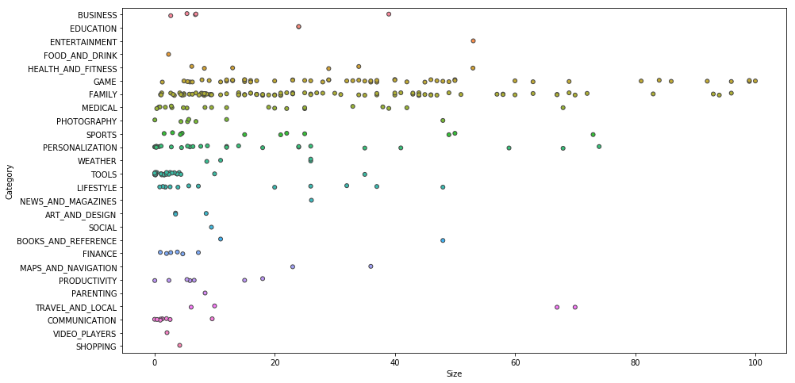

```python
fig, ax = plt.subplots()
fig.set_size_inches(15, 8)
p = sns.stripplot(x="Size", y="Category", data=df_fix1, jitter=True, linewidth=1)
```

Construí y trabajé con ayuda a este gran Kernel: https://www.kaggle.com/lava18/all-that-you-need-to-know-about-the-android-market